# Homework 8

Broderick Prows

3/2/2020

### Part 1

You have gathered mean arterial pressures from ten subjects currently being treated for high blood pressure with a specific drug regimen. You assume these data are (conditionally) normally distributed.

```r
mapr <- c(97.6, 117.7, 126.7, 111.0, 106.7, 108.4, 118.9, 108.6, 119.1, 106.2)
```

1. Compute the log of the likelihood with $\mu = 112$ and $\sigma ^2 = 8.4^2$.

```r
mu <- 112
sd_ <- 8.4
sum( dnorm(mapr, mean = mu, sd = sd_, log= T))
```

```
## [1] -35.01542
```

2. Compute the log of the likelihood with $\mu = \bar{y}$ and $\sigma^2 = \frac{1}{n} \sum_{i=1}^{n}(y_{i} - \bar{y})^2$ where $\bar{y} \equiv \frac{1}{n} \sum_{i=1}^{n} y_{i}$

```r
y_bar <- mean(mapr)
sd_y <- sum((mapr - y_bar)**2) / length(mapr)
sum( dnorm(mapr, mean = y_bar, sd = sqrt(sd_y), log= T))
```

```
## [1] -34.99261
```

3. Now plot the log of the likelihood for values of $\mu$ ranging from 110 to 114 in increments of .05, and with $\sigma^2$ fixed at $\sigma^2 = \frac{1}{n} \sum_{i=1}^{n}(y_{i} - \bar{y})^2$ where $\bar{y} \equiv \frac{1}{n} \sum_{i=1}^{n} y_{i}$

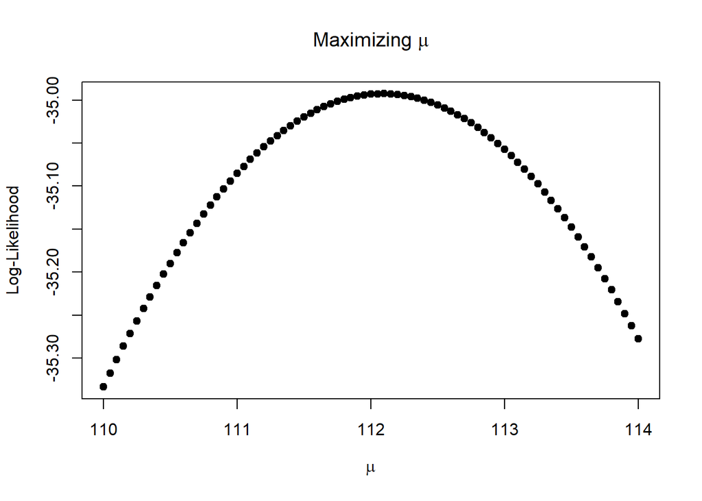

```r
mus <- seq(110,114,by=0.05)
ll_mu <- sapply(mus, function(x) sum( dnorm(mapr, mean = x, sd = sqrt(sd_y), log= T)))
plot(mus, ll_mu,
     xlab = expression(mu), ylab = "Log-Likelihood",
     main = expression(paste("Maximizing ",mu)),
     pch = 19)
```

### Part 2

The population variance of serum cholesterol measurements for urban residents of Guatemala is assumed to be 260. The prior belief about the serum cholesterol of residents of Guatemala is that the population mean, $\mu_{urban}$, should have a mean of 150 with a variance of 90 (and the prior will be a normal distribution).

Here is the total serum cholesterol for eight urban residents of Guatemala:

```r
pop_var_u <- 260
m_u <- 150
v_u <- 90
cholest.u <- c(197, 199, 214, 217, 222, 227, 228, 234)
```

1. What is the posterior distribution of the mean, $\mu_{urban}$, in this case if it is assumed that the data are conditionally iid with a normal distribution?

```r
m_update <- function(m,v,sigma2,y) { #v_star * (n/sigma2*y_bar + 1/v*m)
  n <- length(y)
  y_bar <- mean(y)
  m_star <- (n*v*y_bar + sigma2*m) / (n*v + sigma2)
  return(m_star)
}

v_update <- function(v,sigma2,y) {
  n <- length(y)
  v_star <- (v*sigma2) / (n*v + sigma2)
  return(v_star)
}

m_star_u <- m_update(m_u,v_u,pop_var_u, cholest.u)
v_star_u <- v_update(v_u,pop_var_u,cholest.u)
```

Posterior of $\mu_{urban} \sim$ N(199.41, 23.88).

2. Plot the posterior distribution from part (a).

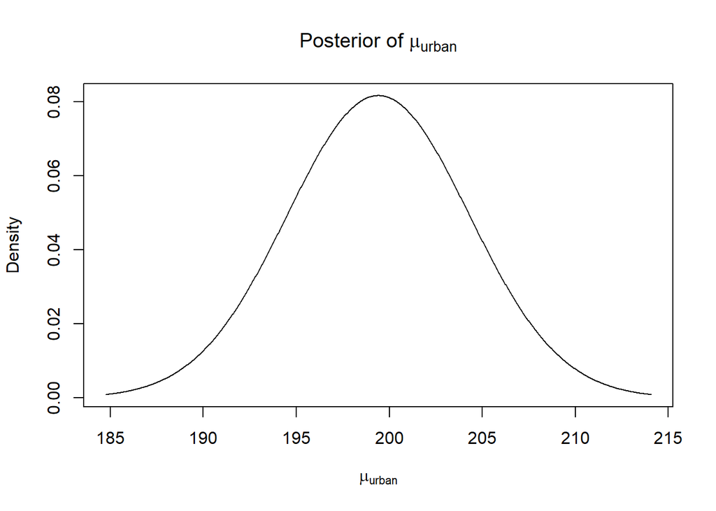

```r
plot_normal <- function(mu, var_, main_title, x_lab, y_lab) {
  sd_ <- sqrt(var_)
  startx <- mu - 3*sd_
  stopx <- mu + 3*sd_
  xs <- seq(startx, stopx, length.out = 1001)
  f_xs <- dnorm(xs, mean = mu, sd_)
  plot(xs, f_xs, main = main_title, xlab = x_lab, ylab = y_lab, type = 'l')
}
plot_normal(m_star_u, v_star_u,
            expression(paste("Posterior of ", mu["urban"])),
            expression(mu["urban"]),
            "Density")
```

### Part 3

The population variance is assumed to be 270. The prior belief about the serum cholesterol of residents of Guatemala is that the population mean, $\mu_{rural}$, should have a mean of 150 with a variance of 90 (and be normally distributed).

Here is the total serum cholesterol for ten rural residents of Guatemala:

```r
cholest.r <- c(139, 142, 143, 144, 145, 148, 155, 162, 171, 181)
```

1. What is the posterior distribution of the mean, $\mu_{rural}$, in this case if it is assumed that the data are conditionally iid with a normal distribution?

```r
pop_var_r <- 270
m_r <- 150
v_r <- 90
m_star_r <- m_update(m_r,v_r,pop_var_r,cholest.r)
v_star_r <- v_update(v_r, pop_var_r,cholest.r)
```

Posterior of $\mu_{rural} \sim$ N(152.31, 20.77).

2. Plot the posterior distribution from part (a).

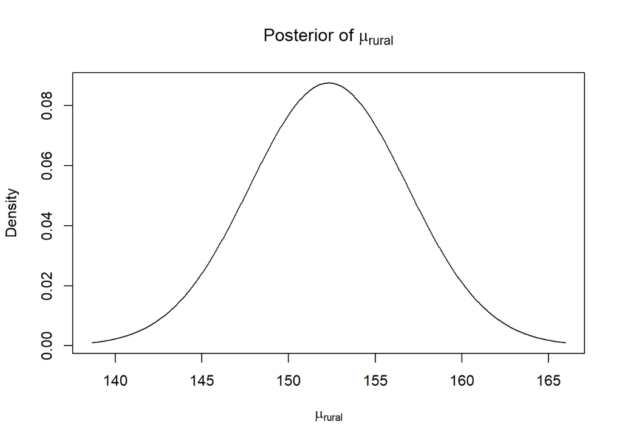

```r
plot_normal(m_star_r, v_star_r,
            expression(paste("Posterior of ", mu["rural"])),
            expression(mu["rural"]),
            "Density")
```

### Part 4

Extending the previous two questions, suppose that the urban data are also assumed to be independent of the rural data. Furthermore, assume that a priori $\mu_{rural}$ is independent of µurban. With these assumptions, $\mu_{rural}$ and $\mu_{urban}$ will also be independent of each other a posteriori. (a) What is the posterior distribution of $\mu_{urban} − \mu_{rural}$?

$$Y = \mu_{urban} - \mu_{rural}$$
Since we assume urban and rural data to be independent,
$$Y \sim N(m^*_{urban} - m^*_{rural}, v^*_{urban} + v^*_{rural})$$

2. Plot the prior and the posterior distribution of $\mu_{urban}$ − $\mu_{rural}$ on the same graph.

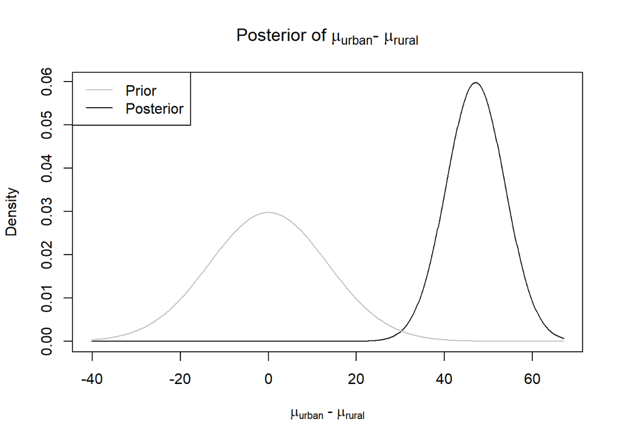

```r
prior_mean <- m_u - m_r
prior_var <- v_u + v_r
prior_start <- prior_mean - 3*sqrt(prior_var)
prior_end <- prior_mean + 3*sqrt(prior_var)

post_mean <- m_star_u - m_star_r
post_var <- v_star_u + v_star_r
post_start <- post_mean - 3*sqrt(post_var)
post_end <- post_mean + 3*sqrt(post_var)

all_start <- min(prior_start, post_start)
all_end <- max(prior_end, post_end)

all_xs <- seq(all_start, all_end, length.out=1001)
prior_dense <- dnorm(all_xs,
                    mean = prior_mean,
                    sd = sqrt(prior_var))
post_dense <- dnorm(all_xs,
                    mean = post_mean,
                    sd = sqrt(post_var))
plot(all_xs, post_dense,
     type='l', col = 'black',
     xlim = c(all_start, all_end),
     main = expression(paste("Posterior of ", mu["urban"], "- ", mu["rural"])),
     xlab = expression(paste(mu["urban"], " - ", mu["rural"])),
     ylab = "Density"
     )
lines(all_xs, prior_dense, type = 'l', col = 'gray')
legend("topleft", c("Prior","Posterior"), lty=1, col = c("gray", "black"))
```

3. State and interpret in the context of this problem the (central) 95% posterior credible interval for $\mu_{urban}$ − $\mu_{rural}$.

```r
qnorm(c(0.025,0.975),mean=post_mean, sd = sqrt(post_var))
```

```
## [1] 34.00434 60.19661
```

There is a 95% probability that the difference between the population mean of the urban residents and rural residents if between 34 and 60. Since this interval does not include 0, we can conclude that urban residents have a significantly higher average serum cholesterol.

### Part 5

The number of immature red tail hawks sitting on fence posts or power poles along a mile-long stretch of rural highway can reasonably be assumed to follow a Poisson distribution. However, we will be comparing data six years apart (in 2003 and then in 2009), and we suspect there might be differences in behavior between 2003 and 2009. Thus, we will assume the observations from 2003 follow the Poisson($\theta_{2003}$) distribution, and the observations from 2009 follow the Poisson($\theta_{2009}$) distribution. We’ll also assume the 2003 data are independent of the 2009 data. Assume that a priori $\theta_{2003}$ and $\theta_{2009}$ are independent of each other.

Along a 10 mile stretch of highway south of Saratoga Springs in 2003, the count of hawks per mile was:

```r
hawks.2003 <- c(0, 2, 0, 0, 0, 4, 3, 0, 0, 1)
```

Along that same stretch of highway in 2009, the counts were:

```r
hawks.2009 <- c(1,1,3,3,2,2,2,4,0,3)
```

1. What is the expected value of the posterior distribution for $\theta_{2003}$ if the prior is a gamma distribution with shape=0.2 and rate=0.2?

```r
a_2003 <- 0.2
b_2003 <- 0.2
a_star_2003 <- a_2003 + sum(hawks.2003)
b_star_2003 <- b_2003 + length(hawks.2003)
a_star_2003 / b_star_2003
```

```
## [1] 1
```

2. What is the expected value of the posterior distribution for $\theta_{2009}$ if the same prior is used as in the previous problem (i.e., Gamma(0.2,0.2)?

```r
a_2009 <- 0.2
b_2009 <- 0.2
a_star_2009 <- a_2009 + sum(hawks.2009)
b_star_2009 <- b_2009 + length(hawks.2009)
a_star_2009 / b_star_2009
```

```
## [1] 2.078431
```

3. What is the expected value of the posterior distribution of $d = \theta_{2009} - \theta_{2003}$?

```r
J <- 10000
sim_2003 <- rgamma(J,shape = a_star_2003, rate = b_star_2003)
sim_2009 <- rgamma(J,shape = a_star_2009, rate = b_star_2009)
diffs <- sim_2009 - sim_2003
mean(diffs)
```

```
## [1] 1.080482
```

4. What is the 95% posterior credible interval for $d$?

```r
quantile(diffs, c(0.025, 0.975))
```

```
##       2.5%      97.5%
## 0.02067633 2.20279173
```

5. Plot the Monte-Carlo estimated posterior distribution of $d = \theta_{2009} - \theta_{2003}$ by using the density and plot functions in R.

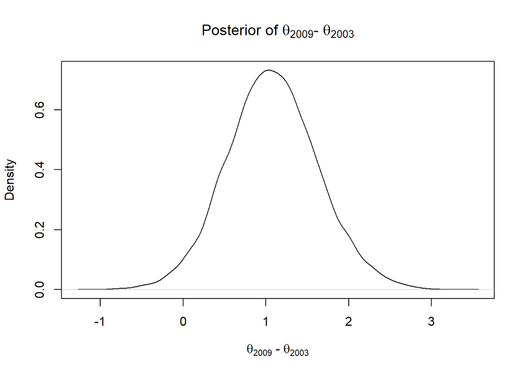

```r
plot(density(diffs),
     main = expression(paste("Posterior of ", theta["2009"], "- ", theta["2003"])),
     xlab = expression(paste(theta["2009"], " - ", theta["2003"])),
     ylab = "Density")
```